# Barriers to digital marketing adoption among DA-SAAD community-based enterprises in Eastern Visayas: A TOE Framework Approach

Author

ViSERDAC

Published

May 7, 2026

# 1 Attachments

**Note**

Copies of the Figures presented in this report are available using the links below. All the files can be accessed in the Google drive folder.

1. [Plots](https://drive.google.com/drive/folders/1jgLLY6bpOs-AI5XP6KoYoz9a4_61FH1i?usp=sharing)
2. [Google Drive](https://drive.google.com/drive/folders/11PzdvQqy8D5A6Ld7rBuzuL8dmG0ykxzI?usp=sharing)

# 2 Objective 1: Describe the organizational, socio-economic, and digital characteristics of DASAAD Phase 2 community-based enterprises in Eastern Visayas.

### Sociodemographic variables

**TipInterpretations**

- **Roles in the Enterprise**
  - Majority of respondents are Presidents (40%), followed by Secretaries (23%) and Treasurers (22%).
- **Age Distribution**
  - Most respondents are 41–50 years old (50%), with 28% aged 51 and above.
  - Leadership is middle-aged to older, suggesting maturity and experience.
- **Sex**
  - Female majority (70%) compared to 30% male.
  - Women play a central role in enterprise leadership and management, which may influence organizational culture and openness to training.
- **Education**
  - Largest group: High school graduates (43%), followed by high school level (28%).
  - Only 19% are college graduates.
  - Educational attainment is modest, with limited higher education exposure, which may constrain digital literacy and adoption capacity.
- **Years Managing & Years Established**
  - Most enterprises are newly managed (1–2 years, 56%) and recently established (1–2 years, 57%).
  - These are young organizations, still in early development stages, which may explain limited adoption of digital marketing practices.
- **Membership Size**
  - Majority have 11–20 members (52%) or 21–30 members (43%).
  - Enterprises are small to medium-sized groups, manageable in scale but possibly lacking economies of scale for digital investments.
- **Farm Size**
  - 61% operate on less than 1 hectare, while 39% have 1–2 hectares.
  - Smallholder enterprises dominate, reinforcing resource constraints and reliance on collective strategies.
- **Income Level**
  - A striking 72% report income above ₱20,000, while smaller groups fall below ₱10,000.
  - Despite small farm sizes, enterprises show relatively strong income levels.
- **Device Availability & Internet Access**
  - 96% have devices, and most access internet via mobile data (34%) or both mobile & WiFi (42%).
  - Device access is nearly universal, but connectivity is mixed, with reliance on mobile data suggesting unstable or limited internet quality.
- **Training Attendance**
  - Only 11% attended training, while 89% did not.
  - Capacity-building is severely lacking, leaving enterprises without formal guidance on digital marketing adoption.
- **Overall Insights**
  - The profile shows female-led, middle-aged, modestly educated, smallholder enterprises with strong income but weak training exposure.
  - Enterprises are young and small in scale, with limited farm sizes but relatively good device access.
  - The biggest gap is in training and capacity-building, which explains why barriers like skills, complexity, and managerial support strongly affect adoption.

```r
df |>
  select(role:attended_training) |>
  select(
    -market,
    -commodity,
    -value_adding_processed_products_specify,
    -organization_name
  ) |>
  tbl_summary(
    statistic = list(all_categorical() ~ "{p}% (n = {n})"),
    type = list(everything() ~ "categorical"),
    missing = "no",
    ,
    label = list(
      role = "Roles",
      age_range ~ "Age",
      sex ~ "Sex",
      education ~ "Education",
      years_managing = "Years managing",
      years_established = "Years established",
      membership_size = "Membership size",
      farm_size = "Farm size",
      income_level = "Income level",
      has_device = "Device availability",
      internet_type = "Internet size",
      attended_training = "Attended training"
    )
  ) |>
  bold_labels() %>%
  as_kable_extra(linesep = "") %>%
  kable_minimal() %>%
  kable_styling(
    full_width = F,
    fixed_thead = T,
    bootstrap_options = c("striped", "hover", "condensed", "responsive")
  )
```

| Characteristic | N = 108 |
| --- | --- |
| Roles |  |
| BOD | 2.8% (n = 3) |
| Business Manager | 5.6% (n = 6) |
| Member | 6.5% (n = 7) |
| President | 40% (n = 43) |
| Secretary | 23% (n = 25) |
| Treasurer | 22% (n = 24) |
| Age |  |
| 18-30 | 2.8% (n = 3) |
| 31-40 | 19% (n = 21) |
| 41-50 | 50% (n = 54) |
| 51 & above | 28% (n = 30) |
| Sex |  |
| Female | 70% (n = 76) |
| Male | 30% (n = 32) |
| Education |  |
| College graduate | 19% (n = 21) |
| College level | 5.6% (n = 6) |
| Elementary graduate | 2.8% (n = 3) |
| Elementary level | 1.9% (n = 2) |
| High school graduate | 43% (n = 46) |
| High school level | 28% (n = 30) |
| Years managing |  |
| 1-2 yrs | 56% (n = 60) |
| 3-5 yrs | 41% (n = 44) |
| less than 1 | 1.9% (n = 2) |
| more than 5 yrs | 1.9% (n = 2) |
| Years established |  |
| 1-2 yrs | 57% (n = 62) |
| 3-5 yrs | 41% (n = 44) |
| more than 5 | 1.9% (n = 2) |
| Membership size |  |
| 11-20 members | 52% (n = 56) |
| 21-30 members | 43% (n = 46) |
| more than 30 | 5.6% (n = 6) |
| Farm size |  |
| 1-2 ha | 39% (n = 42) |
| less than 1 ha | 61% (n = 66) |
| Income level |  |
| 10,001 - 20,000 | 10% (n = 11) |
| 10,001 - 20,001 | 0.9% (n = 1) |
| 5,001 - 10,000 | 4.6% (n = 5) |
| 5,001 - 10,001 | 0.9% (n = 1) |
| Above 20,000 | 72% (n = 78) |
| Below 5,000 | 7.4% (n = 8) |
| less than 5,000 | 3.7% (n = 4) |
| Device availability |  |
| No | 3.7% (n = 4) |
| Yes | 96% (n = 104) |
| Internet size |  |
| Both Mobile & WiFi | 42% (n = 45) |
| Mobile data | 34% (n = 37) |
| None | 1.9% (n = 2) |
| WiFi | 22% (n = 24) |
| Attended training |  |
| No | 89% (n = 96) |
| Yes | 11% (n = 12) |

<sup>1</sup> % (n = n)

### Commodity

**TipInterpretation**

- **Poultry and Fresh Vegetables**
  - Both poultry (35%) and fresh vegetables (35%) are the most common products. These commodities dominate enterprise production, reflecting their accessibility, short production cycles, and strong local demand.
- **Livestock**
  - 12% of enterprises produce livestock. Livestock production is less common but represents a secondary source of income and diversification for some enterprises.
- **Processed Products**
  - 8% of enterprises engage in processing (e.g., value-added goods). While limited, this group shows potential for higher-value activities that can improve profitability and market reach.
- **Corn**
  - 7% of enterprises produce corn. Corn is a staple crop but relatively underrepresented.
- **Fruits**
  - 2% of enterprises produce fruits. Fruit production is minimal, suggesting either limited suitability of land or lower prioritization compared to faster-turnover commodities like poultry and vegetables.

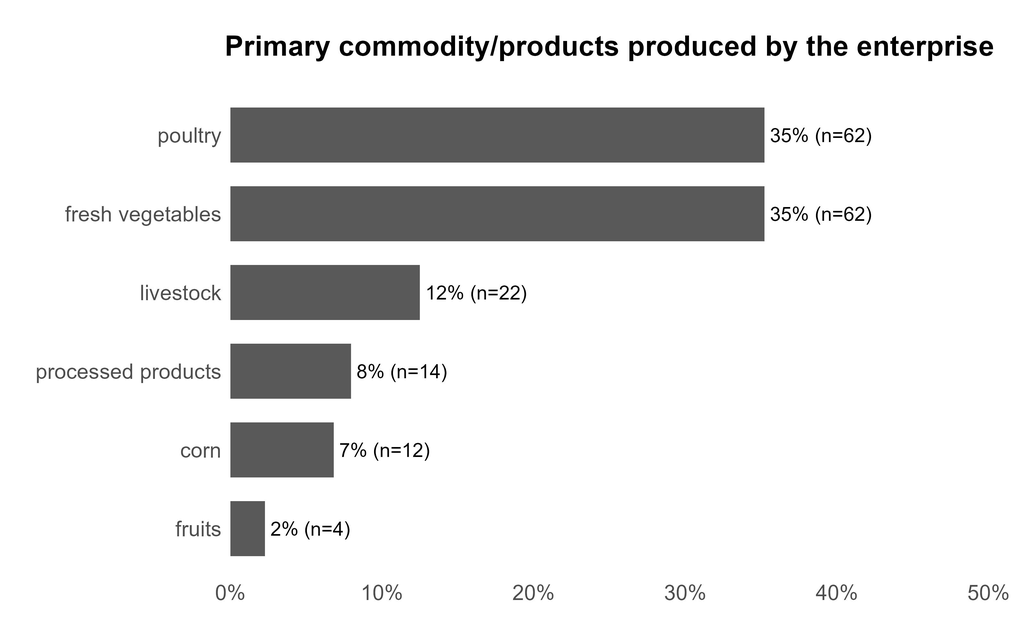

```r
p_commodity <-
  commodity_dta |>
  count(commodity) |>
  mutate(
    pct = n / sum(n),
    pct_lab = str_c(" ", round(pct * 100, 0), "% (n=", n, ")")
  ) |>
  mutate(commodity = fct_reorder(commodity, pct)) |>
  ggplot(aes(pct, commodity)) +
  geom_col(width = 0.7) +
  geom_text(aes(label = pct_lab), hjust = 0) +
  scale_x_continuous(
    labels = percent_format(),
    limits = c(0, 0.5),
    expand = c(0, 0)
  ) +
  labs(
    title = "Primary commodity/products produced by the enterprise",
    x = NULL,
    y = NULL
  ) +
  custom_theme

## saving plot
ggsave(
  plot = p_commodity,
  filename = "plot/commodity.jpeg",
  width = 8,
  height = 5,
  dpi = 400,
  unit = "in"
)

## display plot
knitr::include_graphics("plot/commodity.jpeg")
```

### Market

**TipInterpretation**

- **Direct selling**
  - 38% of enterprises rely on direct selling as their main channel. This reflects a preference for immediate, face-to-face transactions that provide direct access to customers and reduce dependence on intermediaries.
- **Trader**
  - 27% of enterprises sell through traders. This indicates continued reliance on traditional intermediaries, which provide market access but often reduce bargaining power and profit margins.
- **Online**
  - 15% of enterprises use online channels. Adoption of digital platforms is emerging but still limited, showing early-stage integration of digital marketing practices.
- **Public market**
  - 12% of enterprises sell in public markets. This remains a common traditional channel, offering visibility but limited reach beyond local communities.
- **Institutional buyer**
  - 8% of enterprises supply institutional buyers. While smaller in share, this channel provides stable demand and potential for long-term contracts.
- **Kadiwa**
  - 1% of enterprises use Kadiwa (government-supported market linkage).This very low usage suggests limited awareness or accessibility of government-supported marketing initiatives.

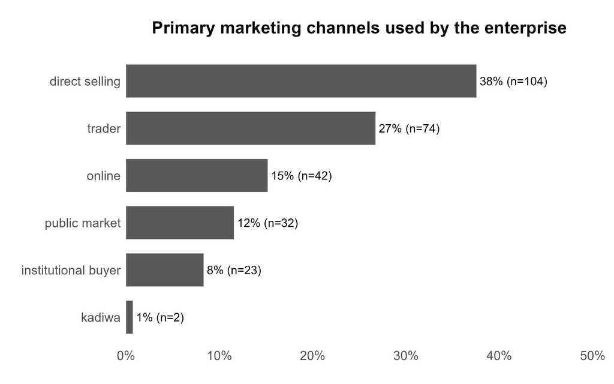

```r
p_market <-
  market_dta |>
  mutate(
    pct = n / sum(n),
    pct_lab = str_c(" ", round(pct * 100, 0), "% (n=", n, ")")
  ) |>
  mutate(market = fct_reorder(market, pct)) |>
  ggplot(aes(pct, market)) +
  geom_col(width = 0.7) +
  geom_text(aes(label = pct_lab), hjust = 0) +
  scale_x_continuous(
    labels = percent_format(),
    limits = c(0, 0.5),
    expand = c(0, 0)
  ) +
  labs(
    title = "Primary marketing channels used by the enterprise",
    x = NULL,
    y = NULL
  ) +
  custom_theme

## saving plot
ggsave(
  plot = p_market,
  filename = "plot/market.jpeg",
  width = 8,
  height = 5,
  dpi = 400,
  unit = "in"
)

## display plot
knitr::include_graphics("plot/market.jpeg")
```

### Value-adding

**TipInterpretation**

- Tablea and banana chips are the leading value-added products, showing enterprises’ focus on culturally relevant and snack-based commodities.
- Other products (coconut oil, vinegar, spreads, cassava cake, etc.) are produced by smaller groups, reflecting diversification and experimentation.
- Value-adding activities remain fragmented and small-scale, but they highlight enterprises’ interest in moving beyond raw commodities toward processed goods.
- These products represent opportunities for training, branding, and market development, especially in niche and specialty markets.

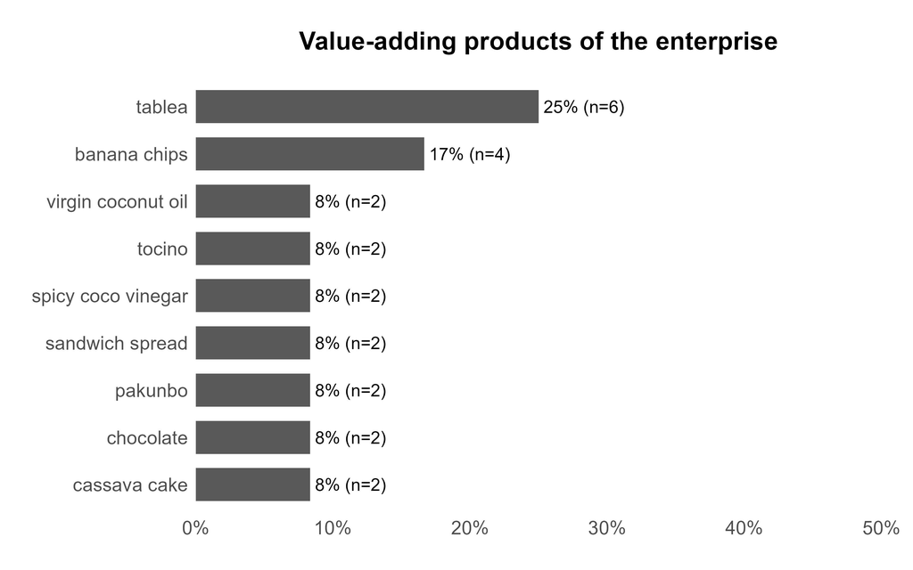

```r
p_value_adding <-
  value_adding_spec_dta |>
  count(value_adding_spec) |>
  mutate(
    pct = n / sum(n),
    pct_lab = str_c(" ", round(pct * 100, 0), "% (n=", n, ")")
  ) |>
  mutate(value_adding_spec = fct_reorder(value_adding_spec, pct)) |>
  ggplot(aes(pct, value_adding_spec)) +
  geom_col(width = 0.7) +
  geom_text(aes(label = pct_lab), hjust = 0) +
  scale_x_continuous(
    labels = percent_format(),
    limits = c(0, 0.5),
    expand = c(0, 0)
  ) +
  labs(
    title = "Value-adding products of the enterprise",
    x = NULL,
    y = NULL
  ) +
  custom_theme

## saving plot
ggsave(
  plot = p_value_adding,
  filename = "plot/value_adding.jpeg",
  width = 8,
  height = 5,
  dpi = 400,
  unit = "in"
)

## display plot
knitr::include_graphics("plot/value_adding.jpeg")
```

# 3 Objective 2: Assess the level of digital marketing adoption among DA-SAAD Phase 2 community-based enterprises in Eastern Visayas.

## 3.1 Tecnological barriers

### Limited digital infrastructure

**TipInterpretation**

- 41% agree and 43% strongly agree that poor connectivity limits digital marketing activities. Only 17% are neutral, showing that connectivity is a major barrier consistently felt across enterprises.
- 46% agree and 20% strongly agree that facilities are inadequate, while 33% are neutral. The result indicates that while many enterprises recognize infrastructure gaps, a significant proportion remain undecided, possibly reflecting uneven access across locations.
- in terms of limited access to smartphones or digital devices, 48% agree and 19% strongly agree, with 33% neutral.

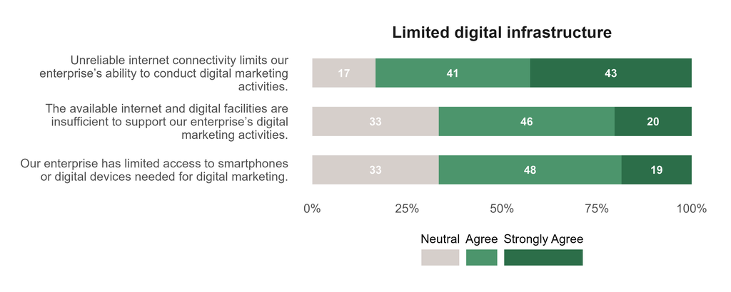

```r
p_limited_digital_infra <- plot_factor(factor_name = "Limited digital infra")

## saving plot
ggsave(
  plot = p_limited_digital_infra,
  filename = "plot/fct_limited_digital_infra.jpeg",
  width = 10,
  height = 4,
  dpi = 400,
  unit = "in"
)

## display plot
knitr::include_graphics("plot/fct_limited_digital_infra.jpeg")
```

### Technological complexity

**TipInterpretation**

- Many enterprises acknowledge challenges in comprehension, but a large neutral group indicates uneven familiarity with tools. Around 41% agree and 2% strongly agree that tools are difficult to understand. Over half (56%) are neutral, suggesting uncertainty or limited exposure.
- In terms of complexity of using the platform, 42% agree and 5% strongly agree that platforms are complicated to use. While 52% are neutral, and only 2% disagree.
- 62% agree and 19% strongly agree that handling multiple platforms is complicated and 19% are neutral, with no disagreement.

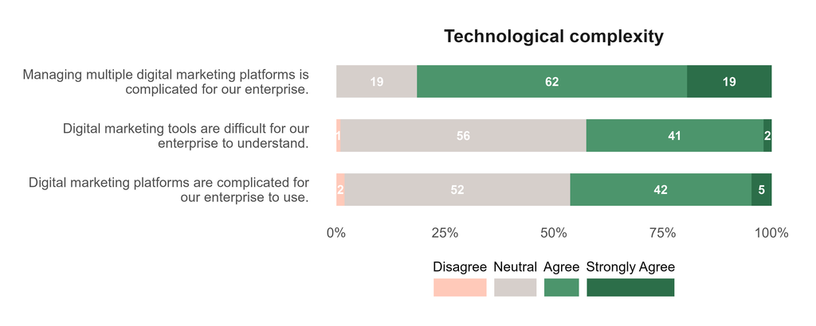

```r
p_technological_complexity <- plot_factor(
  factor_name = "Technological complexity"
)

## saving plot
ggsave(
  plot = p_technological_complexity,
  filename = "plot/fct_technological_complexity.jpeg",
  width = 10,
  height = 4,
  dpi = 400,
  unit = "in"
)

## display plot
knitr::include_graphics("plot/fct_technological_complexity.jpeg")
```

## 3.2 Organizational barriers

### Limited digital skills

**TipInterpretation**

- 60% agree and 25% strongly agree that members lack the skills needed for digital marketing while only 15% are neutral or disagree.
- Wheresas, few members capable of managing tools,46% agree and 42% strongly agree, while just 12% are neutral or disagree.
- In terms of limited knowledge in creating/managing online content, 56% agree and 28% strongly agree, with 16% neutral.
- Result implies that content creation and management is another significant weakness, showing enterprises struggle not only with technical tool use but also with producing digital marketing materials.

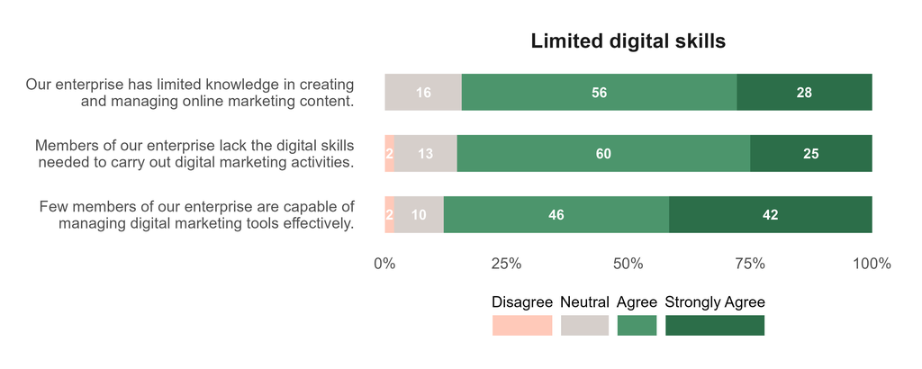

```r
p_limited_digi_skill <- plot_factor(factor_name = "Limited digital skills")

## saving plot
ggsave(
  plot = p_limited_digi_skill,
  filename = "plot/fct_limited_digi_skill.jpeg",
  width = 10,
  height = 4,
  dpi = 400,
  unit = "in"
)

## display plot
knitr::include_graphics("plot/fct_limited_digi_skill.jpeg")
```

### Lack of managerial support

**TipInterpretation**

- In terms of, leaders who do not strongly encourage digital marketing, 67% are neutral, 27% agree, and only 2% strongly agree. Most respondents are undecided, but about one-third perceive weak encouragement from leadership.
- While in terms of limited guidance for implementing digital marketing, 30% agree and 13% strongly agree, while 56% are neutral. A significant portion feels guidance is lacking, but the majority remain neutral.
- 31% agree and 3% strongly agree, with 64% neutral on digital marketing not prioritized by leadership.

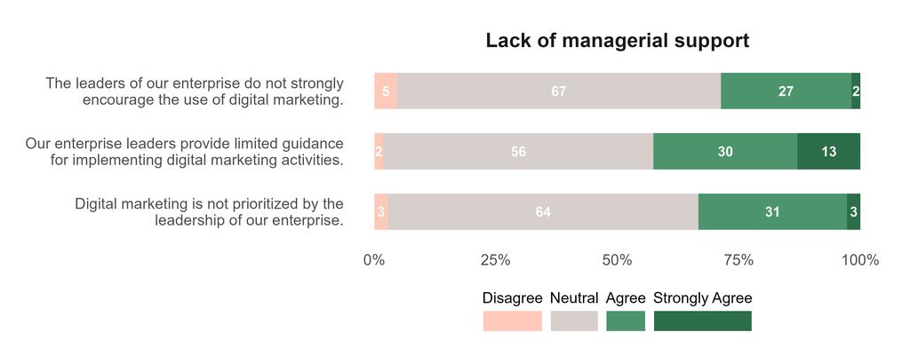

```r
p_lack_managerial_support <- plot_factor(
  factor_name = "Lack of managerial support"
)

## saving plot
ggsave(
  plot = p_lack_managerial_support,
  filename = "plot/fct_lack_managerial_support.jpeg",
  width = 10,
  height = 4,
  dpi = 400,
  unit = "in"
)

## display plot
knitr::include_graphics("plot/fct_lack_managerial_support.jpeg")
```

## 3.3 Environmental barriers

### Limited government support

**TipInterpretation**

- 48% agree and 19% strongly agree that enterprises receive limited training or assistance from government agencies. About 31% are neutral, and only 2% disagree.
- Regarding, few government programs supporting adoption, 42% agree, but 55% are neutral, with only 2% strongly agree. Many respondents are unsure about program availability, suggesting low awareness or visibility of government initiatives.
- 59% agree and 6% strongly agree, while 33% are neutral that there is a limited technical guidance from agencies.

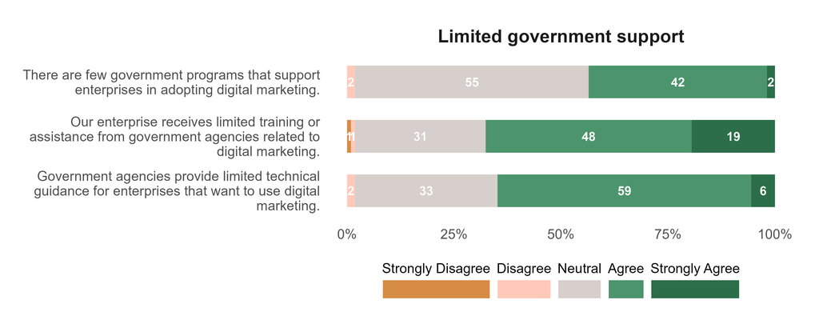

```r
p_limited_gov_suppoprt <- plot_factor(
  factor_name = "Limited government support"
)

## saving plot
ggsave(
  plot = p_limited_gov_suppoprt,
  filename = "plot/fct_limited_gov_suppoprt.jpeg",
  width = 10,
  height = 4,
  dpi = 400,
  unit = "in"
)

## display plot
knitr::include_graphics("plot/fct_limited_gov_suppoprt.jpeg")
```

## 3.4 Digital marketing adoption

**TipInterpretation**

[figure not shown]

```r
p_digital_marketing_adoptino <- plot_factor(
  factor_name = "Digital marketing adoption"
)

## saving plot
ggsave(
  plot = p_digital_marketing_adoptino,
  filename = "plot/fct_digital_marketing_adoptino.jpeg",
  width = 10,
  height = 5,
  dpi = 400,
  unit = "in"
)

## display plot
knitr::include_graphics("plot/fct_digital_marketing_adoptino.jpeg")
```

# 4 Objective 3-5: Assess the technological, organizational, and environmental barriers affecting digital marketing adoption among DA-SAAD Phase 2 community-based enterprises in Eastern Visayas.

## 4.1 Exploratory Factor Analysis

### Parallel analysis

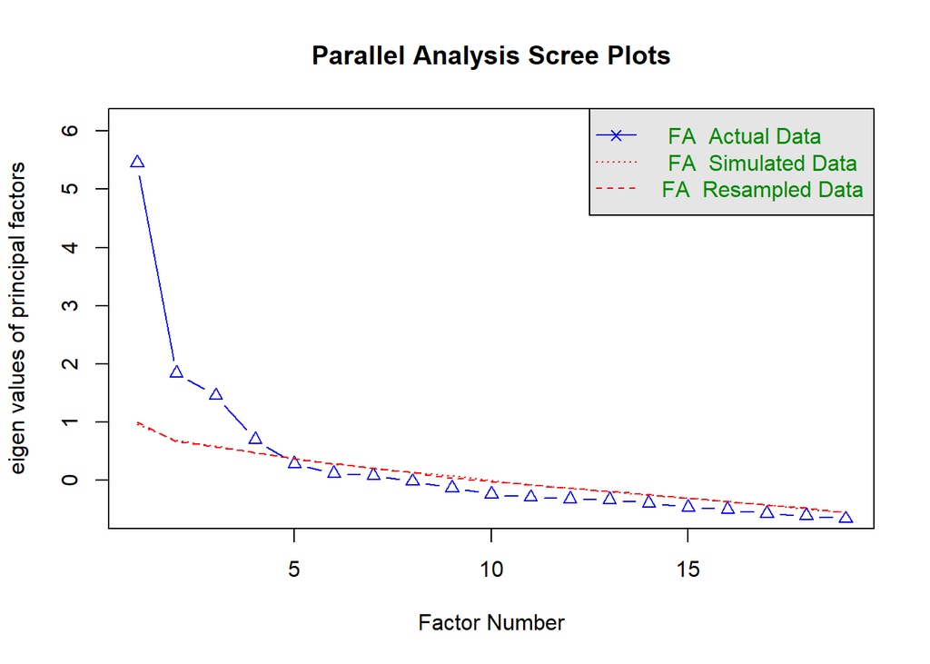

```
Parallel analysis suggests that the number of factors =  4  and the number of components =  NA
```

```r
fct_lkrt_dta <-
  df |>
  select(tb1:dma19)

fa.parallel(fct_lkrt_dta, fa = "fa")
```

### Factor extraction

```r
efa_extract <- fa(
  r = fct_lkrt_dta,
  nfactors = 6,
  rotat = "varimax",
  fm = "ml"
)

print(efa_extract$loadings, cutoff = 0.3, sort = TRUE)
```

```
Loadings:
      ML1    ML4    ML5    ML2    ML3    ML6
dma16  0.854
dma17  0.510 -0.437               -0.305
dma18  0.749
dma19  0.967
tb1           0.719
tb2           0.780  0.308
tb3           0.847
tb4   -0.307  0.394  0.549
tb5   -0.308         0.609
tb6                  0.538
ob8                  0.738  0.367
ob9                  0.715                0.320
eb14                        0.620
eb15                        0.951
ob11  -0.334                       0.897
ob12                        0.311  0.742  0.332
ob7           0.339  0.387
ob10          0.425
eb13                        0.446

                 ML1   ML4   ML5   ML2   ML3   ML6
SS loadings    2.956 2.714 2.572 1.902 1.666 0.533
Proportion Var 0.156 0.143 0.135 0.100 0.088 0.028
Cumulative Var 0.156 0.298 0.434 0.534 0.622 0.650
```

## 4.2 PLS-SEM

### Boostrapped PLS-SEM

**TipTechnological complexity → Digital marketing adoption**

**TipLack of managerial support → Digital marketing adoption**

- β = -0.334, p < 0.001 (significant)
- Weak encouragement, guidance, and prioritization from leaders strongly hinders adoption Leadership passivity or lack of vision is a critical organizational barrier.

**TipLimited digital infrastructure → Digital marketing adoption**

**TipLimited government support → Digital marketing adoption**

**TipLimited digital skills → Digital marketing adoption**

```r
# defining measurment model
measurement_model <- constructs(
  composite("Limited digital infrastructure", multi_items("tb", 1:3)),

  composite("Technological complexity", multi_items("tb", 4:6)),

  composite("Limited digital skills", multi_items("ob", 7:9)),

  composite("Lack managerial support", multi_items("ob", 10:12)),

  composite("Limited government support", multi_items("eb", 13:15)),

  composite("Digital marketing adoption", multi_items("dma", 16:19))
)

# defining structural model
structural_model <- relationships(
  paths(
    from = c(
      "Limited digital infrastructure",
      "Technological complexity",
      "Limited digital skills",
      "Lack managerial support",
      "Limited government support"
    ),
    to = "Digital marketing adoption"
  )
)

# estimate model
pls_model <- estimate_pls(
  data = fct_lkrt_dta,
  measurement_model = measurement_model,
  structural_model = structural_model
)

# run bootstrapped model
boot_pls <- bootstrap_model(
  seminr_model = pls_model,
  nboot = 5000, # number of bootstrap samples
  cores = 4 # use multiple cores for speed
)


plot(boot_pls)
```

[interactive chart not shown]

```r
## summary table
summ_boot_pls_model <- summary(boot_pls)

DT::datatable(summ_boot_pls_model$bootstrapped_paths |> round(3))
```

|  | Original Est. | Bootstrap Mean | Bootstrap SD | T Stat. | 2.5% CI | 97.5% CI | Bootstrap P Val |
| --- | --- | --- | --- | --- | --- | --- | --- |
| Limited digital infrastructure -&gt; Digital marketing adoption | -0.171 | -0.153 | 0.081 | -2.124 | -0.322 | 0.002 | 0.052 |
| Technological complexity -&gt; Digital marketing adoption | -0.344 | -0.336 | 0.101 | -3.409 | -0.531 | -0.136 | 0.003 |
| Limited digital skills -&gt; Digital marketing adoption | 0.058 | -0.011 | 0.116 | 0.505 | -0.229 | 0.22 | 0.907 |
| Lack managerial support -&gt; Digital marketing adoption | -0.334 | -0.342 | 0.07 | -4.771 | -0.48 | -0.207 | 0 |
| Limited government support -&gt; Digital marketing adoption | -0.061 | 0.146 | 0.162 | -0.377 | -0.167 | 0.408 | 0.43 |

### Reliability test

**TipReliability indicators**

- **Limited digital infrastructure**
  - α = 0.843, rhoA = 0.845, rhoC = 0.905, AVE = 0.761
  - All values exceed thresholds.
  - High reliability and convergent validity. Items consistently measure the construct and capture sufficient variance.
- **Technological complexity**
  - α = 0.732, rhoA = 0.774, rhoC = 0.848, AVE = 0.654
  - All values exceed thresholds.
  - Strong reliability and validity. Indicators are consistent and explain a good portion of variance.
- **Limited digital skills**
  - α = 0.735, rhoA = 0.771, rhoC = 0.841, AVE = 0.640
  - All values exceed thresholds.
  - Reliable and valid construct. Skills-related items are consistent and capture variance well.
- **Lack of managerial support**
  - α = 0.660 (slightly below 0.7), rhoA = 0.777, rhoC = 0.812, AVE = 0.600
  - Cronbach’s alpha is marginally below threshold, but rhoA, rhoC, and AVE meet criteria.
  - Acceptable reliability. Internal consistency is weaker, suggesting items may reflect different aspects of managerial support, but overall validity is adequate.
- **Limited government support**
  - α = 0.716 (acceptable), rhoA = -0.660 (problematic), rhoC = 0.225 (far below threshold), AVE = 0.280 (below threshold).
  - Reliability and validity are low. Indicators do not consistently measure the construct, and convergent validity is not achieved.
- **Digital marketing adoption**
  - α = 0.887, rhoA = 0.888, rhoC = 0.922, AVE = 0.748
  - All values exceed thresholds.
  - Excellent reliability and validity. Adoption items are highly consistent and capture strong variance.

```r
## summary of pls model
summ_pls_model <- summary(pls_model)

DT::datatable(round(summ_pls_model$reliability, 3))
```

|  | alpha | rhoA | rhoC | AVE |
| --- | --- | --- | --- | --- |
| Limited digital infrastructure | 0.843 | 0.845 | 0.905 | 0.761 |
| Technological complexity | 0.732 | 0.774 | 0.848 | 0.654 |
| Limited digital skills | 0.735 | 0.771 | 0.841 | 0.64 |
| Lack managerial support | 0.66 | 0.777 | 0.812 | 0.6 |
| Limited government support | 0.716 | -0.66 | 0.225 | 0.28 |
| Digital marketing adoption | 0.887 | 0.888 | 0.922 | 0.748 |

### Validity test

**TipFornell-Larcker Criterion**

- **Diagonal values (√AVE)**
  - Limited digital infrastructure = 0.872
  - Technological complexity = 0.809
  - Limited digital skills = 0.800
  - Lack managerial support = 0.775
  - Limited government support = 0.529
  - Digital marketing adoption = 0.865
  - Rule: Each diagonal value should be greater than its correlations with other constructs.
- **Limited digital infrastructure (0.872)**
  - Higher than correlations with technological complexity (0.464), skills (0.380), managerial support (0.180), government support (0.087), and adoption (-0.374).
  - Strong discriminant validity.
- **Technological complexity (0.809)**
  - Higher than correlations with infrastructure (0.464), skills (0.646), managerial support (0.301), government support (0.215), and adoption (-0.499).
  - Valid and distinct, though correlation with skills (0.646) is moderately high, suggesting overlap.
- **Limited digital skills (0.800)**
  - Higher than correlations with infrastructure (0.380), complexity (0.646), managerial support (0.388), government support (0.189), and adoption (-0.370).
  - Valid construct, but again moderately correlated with complexity (0.646).
- **Lack managerial support (0.775)**
  - Higher than correlations with infrastructure (0.180), complexity (0.301), skills (0.388), government support (0.221), and adoption (-0.459).
  - Valid and distinct.
- **Digital marketing adoption (0.865)**
  - Higher than correlations with infrastructure (-0.374), complexity (-0.499), skills (-0.370), managerial support (-0.459), and government support (-0.212).
  - Strong discriminant validity.

```r
DT::datatable(round(summ_pls_model$validity$fl_criteria, 3))
```

|  | Limited digital infrastructure | Technological complexity | Limited digital skills | Lack managerial support | Limited government support | Digital marketing adoption |
| --- | --- | --- | --- | --- | --- | --- |
| Limited digital infrastructure | 0.872 |  |  |  |  |  |
| Technological complexity | 0.464 | 0.809 |  |  |  |  |
| Limited digital skills | 0.38 | 0.646 | 0.8 |  |  |  |
| Lack managerial support | 0.18 | 0.301 | 0.388 | 0.775 |  |  |
| Limited government support | 0.087 | 0.215 | 0.189 | 0.221 | 0.529 |  |
| Digital marketing adoption | -0.374 | -0.499 | -0.37 | -0.459 | -0.212 | 0.865 |